# Cox Survival Analysis for HGG Samples

## Calculate risk score for training set and predict for test set

First calculate for SLC7A5

```r
train_risk_slc7a5_pfs <- predict(coxph_train_slc7a5_pfs, type = "risk")
med_risk_slc7a5_pfs <- median(train_risk_slc7a5_pfs)
med_risk_slc7a5_pfs
```

```
## [1] 0.6943294
```

```r
test_risk_slc7a5_pfs <- predict(coxph_train_slc7a5_pfs, newdata = data_test, type = "risk") %>%
  as.data.frame() %>% cbind(data_test) %>%
  dplyr::rename("RiskScore" = ".") %>%
  dplyr::mutate(RiskGroup = case_when(
    RiskScore > med_risk_slc7a5_pfs ~ "High",
    RiskScore <= med_risk_slc7a5_pfs ~ "Low"
  ))

test_risk_slc7a5_pfs$RiskGroup <- as.factor(test_risk_slc7a5_pfs$RiskGroup)
```

Then calculate for FOLH1

```r
train_risk_folh1_pfs <- predict(coxph_train_folh1_pfs, type = "risk")
med_risk_folh1_pfs <- median(train_risk_folh1_pfs)
med_risk_folh1_pfs
```

```
## [1] 0.902799
```

```r
test_risk_folh1_pfs <- predict(coxph_train_folh1_pfs, newdata = data_test, type = "risk") %>%
  as.data.frame() %>% cbind(data_test) %>%
  dplyr::rename("RiskScore" = ".") %>%
  dplyr::mutate(RiskGroup = case_when(
    RiskScore > med_risk_folh1_pfs ~ "High",
    RiskScore <= med_risk_folh1_pfs ~ "Low"
  ))

test_risk_folh1_pfs$RiskGroup <- as.factor(test_risk_folh1_pfs$RiskGroup)
```

## Now run Cox analyses per gene for RiskScore and RiskGroup

First calculate per risk group for SLC7A5

```r
coxph_riskgroup_slc7a5_pfs <- survival::coxph(formula = Surv(PFS_days, PFS_status) ~  RiskGroup,
                                              data = test_risk_slc7a5_pfs)
coxph_riskgroup_slc7a5_pfs_sum <- as.data.frame(summary(coxph_riskgroup_slc7a5_pfs)$coefficients) %>%
  rownames_to_column()
coxph_riskgroup_slc7a5_pfs_sum %>% knitr::kable()
```

| rowname | coef | exp(coef) | se(coef) | z | Pr(>\|z\|) |
| --- | --- | --- | --- | --- | --- |
| RiskGroupLow | -1.506956 | 0.2215834 | 0.8020844 | -1.8788 | 0.0602718 |

Calculate per risk score for SLC7A5

```r
coxph_riskscore_slc7a5_pfs <- survival::coxph(formula = Surv(PFS_days, PFS_status) ~  RiskScore,
                                              data = test_risk_slc7a5_pfs)
coxph_riskscore_slc7a5_pfs_sum <- as.data.frame(summary(coxph_riskscore_slc7a5_pfs)$coefficients) %>%
  rownames_to_column()
coxph_riskscore_slc7a5_pfs_sum %>% knitr::kable()
```

| rowname | coef | exp(coef) | se(coef) | z | Pr(>\|z\|) |
| --- | --- | --- | --- | --- | --- |
| RiskScore | 0.662827 | 1.94027 | 0.4715563 | 1.405616 | 0.1598382 |

Saving results for SLC7A5 results:

```r
coxph_test_results_pfs_dir <- file.path(coxph_test_results_dir, "PFS")

if (!dir.exists(coxph_test_results_pfs_dir )) {
  dir.create(coxph_test_results_pfs_dir , recursive = TRUE)
}

write_tsv(coxph_riskgroup_slc7a5_pfs_sum, file.path(coxph_test_results_pfs_dir, "coxph_test_riskgroup_slc7a5_pfs_sum.tsv"))
write_tsv(coxph_riskscore_slc7a5_pfs_sum,  file.path(coxph_test_results_pfs_dir, "coxph_test_riskscore_slc7a5_pfs_sum.tsv"))
```

Then calculate per risk group for FOLH1

```r
coxph_riskgroup_folh1_pfs <- survival::coxph(formula = Surv(PFS_days, PFS_status) ~  RiskGroup,
                                             data = test_risk_folh1_pfs)
coxph_riskgroup_folh1_pfs_sum <- as.data.frame(summary(coxph_riskgroup_folh1_pfs)$coefficients) %>%
  rownames_to_column()
coxph_riskgroup_folh1_pfs_sum %>% knitr::kable()
```

| rowname | coef | exp(coef) | se(coef) | z | Pr(>\|z\|) |
| --- | --- | --- | --- | --- | --- |
| RiskGroupLow | -0.6317829 | 0.5316431 | 0.6811331 | -0.927547 | 0.3536426 |

Calculate per risk score for FOLH1

```r
coxph_riskscore_folh1_pfs <- survival::coxph(formula = Surv(PFS_days, PFS_status) ~  RiskScore,
                                             data = test_risk_folh1_pfs)
coxph_riskscore_folh1_pfs_sum <- as.data.frame(summary(coxph_riskscore_folh1_pfs)$coefficients) %>%
  rownames_to_column()
coxph_riskscore_folh1_pfs_sum %>% knitr::kable()
```

| rowname | coef | exp(coef) | se(coef) | z | Pr(>\|z\|) |
| --- | --- | --- | --- | --- | --- |
| RiskScore | -0.0282288 | 0.9721659 | 0.1882405 | -0.1499614 | 0.8807951 |

Saving results for FOLH1 results:

```r
write_tsv(coxph_riskgroup_folh1_pfs_sum,  file.path(coxph_test_results_pfs_dir, "coxph_test_riskgroup_folh1_pfs_sum.tsv"))
write_tsv(coxph_riskscore_folh1_pfs_sum,  file.path(coxph_test_results_pfs_dir, "coxph_test_riskscore_folh1_pfs_sum.tsv"))
```

## Finally plot the survival for each gene per risk group

First generate plot for SLC7A5

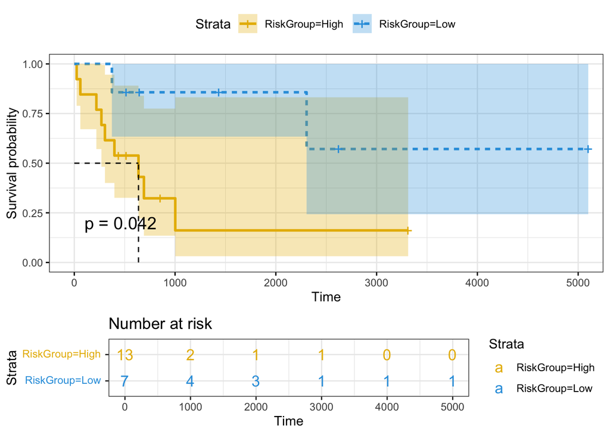

```r
fit_slc7c5_pfs <- survfit(Surv(PFS_days, PFS_status) ~ RiskGroup, data = test_risk_slc7a5_pfs)
plot_coxph_riskgroup_slc7a5_pfs <- survminer::ggsurvplot(fit_slc7c5_pfs,
           data=test_risk_slc7a5_pfs,
           pval = TRUE,
           conf.int = TRUE,
           risk.table = TRUE, # Add risk table
           risk.table.col = "strata", # Change risk table color by groups
           linetype = "strata", # Change line type by groups
           surv.median.line = "hv", # Specify median survival
           ggtheme = theme_bw(), # Change ggplot2 theme
           palette = c("#E7B800", "#2E9FDF"))

# Make this plot a combined plot
surv_plot_slc7a5_pfs<- cowplot::plot_grid(plot_coxph_riskgroup_slc7a5_pfs[[1]],
                                       plot_coxph_riskgroup_slc7a5_pfs[[2]],
                                       nrow = 2,
                                       rel_heights = c(2.5, 1))
# Print it out here
surv_plot_slc7a5_pfs
```

```r
cox_survival_plots_pfs_dir <- file.path(cox_survival_plots_dir, "PFS")
if (!dir.exists(cox_survival_plots_pfs_dir )) {
  dir.create(cox_survival_plots_pfs_dir , recursive = TRUE)
}

# Save the plot
cowplot::save_plot(filename = file.path(cox_survival_plots_pfs_dir, "coxph_riskgroup_slc7a5_pfs_survival.png"), plot = surv_plot_slc7a5_pfs)
```

Second generate plot for FOLH1

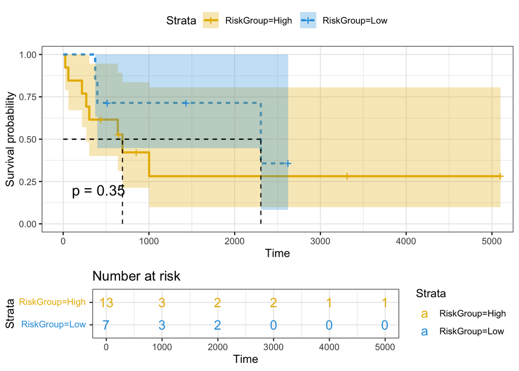

```r
fit_folh1_pfs <- survfit(Surv(PFS_days, PFS_status) ~ RiskGroup, data = test_risk_folh1_pfs)
plot_coxph_riskgroup_folh1_pfs <- survminer::ggsurvplot(fit_folh1_pfs,
           data=test_risk_folh1_pfs,
           pval = TRUE,
           conf.int = TRUE,
           risk.table = TRUE, # Add risk table
           risk.table.col = "strata", # Change risk table color by groups
           linetype = "strata", # Change line type by groups
           surv.median.line = "hv", # Specify median survival
           ggtheme = theme_bw(), # Change ggplot2 theme
           palette = c("#E7B800", "#2E9FDF"))

# Make this plot a combined plot
surv_plot_folh1_pfs <- cowplot::plot_grid(plot_coxph_riskgroup_folh1_pfs[[1]],
                                          plot_coxph_riskgroup_folh1_pfs[[2]],
                                          nrow = 2,
                                          rel_heights = c(2.5, 1))
# Print it out here
surv_plot_folh1_pfs
```

```r
# Save the plot
cowplot::save_plot(filename = file.path(cox_survival_plots_pfs_dir, "coxph_riskgroup_folh1_pfs_survival.png"), plot = surv_plot_folh1_pfs)
```